# Decision-Making Study

- Show All Code
- Hide All Code
- View Source

PSY 120L Reproducible Analysis Report

Author

Taralynn Kang

Published

June 6, 2026

### About This Report

This study examines the relationship between Perceived Peer Norms, Conscientiousness, Peer Norm Resistance, and levels of Risky Decision-Making in undergraduate college students. The selected statistical analysis consists of a between-subjects two-way ANOVA.

## Study Overview

IV: Risk-Normalizing condition, Risk-Avoiding condition Moderator: Conscientiousness (median split: Low and High) DV1: Level of Risky Decision-Making DV2: Level of Peer Norm Resistance

## Setup and Software Environment

This code is processed in RStudio and Quarto. Packages “tidyverse”, “psych”, “afex”, and “emmeans” are installed, which allow us to manipulate the data to complete statistical analysis.

Load Packages

```r
library(tidyverse)  # data manipulation + plotting
library(psych)      # scale construction + reliability
library(afex)       # ANOVA models + effect sizes
library(emmeans)    # estimated marginal means + confidence intervals
```

## Data Source and Analysis Dataset

The data is imported from Qualtrics, and online survey platform. Participants submit their data anonymously via a Qualtrics survey, and it is imported directly into RStudio.

Import Dataset

```r
study_raw <- read_csv("data/decision_making_data.csv")
```

## Check Imported Dataset

```r
dim(study_raw)
```

```
[1] 65 42
```

```r
names(study_raw)
```

```
 [1] "StartDate"             "EndDate"               "Status"
 [4] "IPAddress"             "Progress"              "Duration (in seconds)"
 [7] "Finished"              "RecordedDate"          "ResponseId"
[10] "ExternalReference"     "LocationLatitude"      "LocationLongitude"
[13] "DistributionChannel"   "UserLanguage"          "consent"
[16] "mc"                    "RTL_1"                 "RTL_2"
[19] "RTL_3"                 "RTL_4"                 "RTL_5"
[22] "PNR_1"                 "PNR_2"                 "PNR_3"
[25] "PNR_4"                 "PNR_5"                 "con_1"
[28] "con_2"                 "con_3"                 "con_4"
[31] "con_5"                 "con_6"                 "con_7"
[34] "con_8"                 "con_9"                 "con_10"
[37] "con_11"                "con_12"                "age"
[40] "academic_year"         "gender"                "condition"
```

```r
head(study_raw)
```

```
# A tibble: 6 × 42
  StartDate    EndDate Status IPAddress Progress Duration (in seconds…¹ Finished
  <chr>        <chr>    <dbl> <chr>        <dbl>                  <dbl>    <dbl>
1 5/5/26 20:03 5/5/26…      0 72.205.8…      100                    146        1
2 5/6/26 10:41 5/6/26…      0 169.231.…      100                    298        1
3 5/6/26 14:03 5/6/26…      0 169.231.…      100                    874        1
4 5/6/26 15:03 5/6/26…      0 169.231.…      100                    211        1
5 5/5/26 19:04 5/6/26…      0 68.6.116…      100                  83227        1
6 5/6/26 22:11 5/6/26…      0 184.187.…      100                    261        1
# ℹ abbreviated name: ¹`Duration (in seconds)`
# ℹ 35 more variables: RecordedDate <chr>, ResponseId <chr>,
#   ExternalReference <lgl>, LocationLatitude <dbl>, LocationLongitude <dbl>,
#   DistributionChannel <chr>, UserLanguage <chr>, consent <dbl>, mc <dbl>,
#   RTL_1 <dbl>, RTL_2 <dbl>, RTL_3 <dbl>, RTL_4 <dbl>, RTL_5 <dbl>,
#   PNR_1 <dbl>, PNR_2 <dbl>, PNR_3 <dbl>, PNR_4 <dbl>, PNR_5 <dbl>,
#   con_1 <dbl>, con_2 <dbl>, con_3 <dbl>, con_4 <dbl>, con_5 <dbl>, …
```

## Create Analysis Dataset

```r
study_vars <- c(
  "condition",  # experimental condition variable
  "age", "academic_year", "gender",

          "RTL_1", "RTL_2", "RTL_3", "RTL_4", "RTL_5",

          "PNR_1", "PNR_2", "PNR_3", "PNR_4", "PNR_5",

          "con_1", "con_2", "con_3", "con_4", "con_5",
          "con_6", "con_7", "con_8", "con_9", "con_10",
          "con_11", "con_12"
)

study_data <- study_raw %>%
  select(all_of(study_vars)) %>%
  mutate(across(everything(), as.numeric))
```

## Check Analysis Dataset

```r
length(study_vars)
```

```
[1] 26
```

```r
dim(study_data)
```

```
[1] 65 26
```

```r
names(study_data)
```

```
 [1] "condition"     "age"           "academic_year" "gender"
 [5] "RTL_1"         "RTL_2"         "RTL_3"         "RTL_4"
 [9] "RTL_5"         "PNR_1"         "PNR_2"         "PNR_3"
[13] "PNR_4"         "PNR_5"         "con_1"         "con_2"
[17] "con_3"         "con_4"         "con_5"         "con_6"
[21] "con_7"         "con_8"         "con_9"         "con_10"
[25] "con_11"        "con_12"
```

This table reflects the names of the specific categories within our measures. PNR = Peer Norm Resistance, RTL = Risk-Taking Likelihood, and Conscientiousness = con_[number].

## Variable Preparation

All variable data has been converted to numerical values. The names of each condition and measurement have been shortened for ease of statistical analysis.

## Prepare Participant ID and Experimental Condition

```r
study_data <- study_data %>%
  mutate(
    id = row_number(),
    condition= factor(
      condition,
      levels = c(0, 1),
      labels = c("Risk-Avoiding", "Risk-Normalizing")
    )
  )
```

This function prepares the dataset by adding a unique identifier for each observation, and also converts the “condition” variable into a factor with description labels (“risk-avoiding”, “risk-normalizing”), which also makes the data easier to interpret and makes sure that the condition variables are categorical.

## Check Experimental Condition Coding

```r
study_data %>%
  count(condition) %>%
  knitr::kable(
    col.names = c("Condition", "n")
  )
```

| Condition | n |
| --- | --- |
| Risk-Avoiding | 31 |
| Risk-Normalizing | 33 |
| NA | 1 |

The condition check confirms the number of participants assigned to each peer norm condition.

## Check Prepared Analysis Dataset

```r
dim(study_data)
```

```
[1] 65 27
```

```r
names(study_data)
```

```
 [1] "condition"     "age"           "academic_year" "gender"
 [5] "RTL_1"         "RTL_2"         "RTL_3"         "RTL_4"
 [9] "RTL_5"         "PNR_1"         "PNR_2"         "PNR_3"
[13] "PNR_4"         "PNR_5"         "con_1"         "con_2"
[17] "con_3"         "con_4"         "con_5"         "con_6"
[21] "con_7"         "con_8"         "con_9"         "con_10"
[25] "con_11"        "con_12"        "id"
```

## Reverse-Code Scale Items

Each original item is subtracted from six, which makes sure that higher values reflect the same construct direction. The values demonstrate the expected inverse relationship, which shows that reverse coding was performed correctly.

```r
study_data <- study_data %>%
  mutate(
    con_1r = 6 - con_1,
    con_2r = 6 - con_2,
    con_5r = 6 - con_5,
    con_6r = 6 - con_6,
    con_10r = 6 - con_10,
    con_12r = 6 - con_12
  )
```

## Check Reverse Coding

```r
study_data %>%
  select(con_1, con_1r) %>%
  head(10) %>%
  knitr::kable()
```

| con_1 | con_1r |
| --- | --- |
| 4 | 2 |
| 1 | 5 |
| 1 | 5 |
| 1 | 5 |
| 2 | 4 |
| 4 | 2 |
| 2 | 4 |
| 1 | 5 |
| 2 | 4 |
| 2 | 4 |

The pattern of values shows that each score has been transformed to its opposite on the scale (e.g., higher original values correspond with lower reversed values). This indicates that the reverse coding procedure was applied accurately.

## Create Scale Scores

The scale scores for Risk-Taking, Peer Norm Resistance, and Conscientiousness were calculated as the means of each measurement’s items. The summary statistic indicates the overall distribution of each scale, and missingness check shows the proportion of absent or missing values. Lower levels of missing data suggests that scale scores were computed successfully and are ready for later analysis.

```r
# Define risk-taking likelihood items
risk_taking_items <- c("RTL_1", "RTL_2", "RTL_3", "RTL_4", "RTL_5")

# Define peer norm resistance items
peer_norm_resistance_items <- c("PNR_1", "PNR_2", "PNR_3", "PNR_4", "PNR_5")

# Define conscientiousness items
conscientiousness_items <- c("con_1r", "con_2r", "con_3", "con_4", "con_5r", "con_6r", "con_7", "con_8", "con_9", "con_10r", "con_11", "con_12r")

# Create scale scores
study_data <- study_data %>%
  mutate(
    risk_taking = rowMeans(across(all_of(risk_taking_items)), na.rm = TRUE),
    peer_norm_resistance = rowMeans(across(all_of(peer_norm_resistance_items)), na.rm = TRUE),
    conscientiousness = rowMeans(across(all_of(conscientiousness_items)), na.rm = TRUE)
  )
```

## Check Scale Scores

```r
study_data %>%
  select(risk_taking, peer_norm_resistance, conscientiousness) %>%
  summary()
```

```
  risk_taking   peer_norm_resistance conscientiousness
 Min.   :1.00   Min.   :3.400        Min.   :2.333
 1st Qu.:2.20   1st Qu.:5.000        1st Qu.:3.250
 Median :2.80   Median :6.000        Median :3.667
 Mean   :2.84   Mean   :5.698        Mean   :3.614
 3rd Qu.:3.40   3rd Qu.:6.400        3rd Qu.:3.917
 Max.   :5.60   Max.   :7.000        Max.   :4.833
```

```r
study_data %>%
  summarise(
    risk_taking_missing = mean(is.na(risk_taking)),
    peer_norm_resistance_missing = mean(is.na(peer_norm_resistance)),
    conscientiousness_missing = mean(is.na(conscientiousness))
  ) %>%
  knitr::kable()
```

| risk_taking_missing | peer_norm_resistance_missing | conscientiousness_missing |
| --- | --- | --- |
| 0 | 0 | 0 |

Summary statistics provide an overview of central tendency and variability for each scale. Missingness analysis shows proportions of missing values for each scale.

## Create Concientiousness Groups

A median split is used to categorize participant data into “low” and “high” conscientiousness groups based on the sample median

```r
conscientiousness_median <- median(study_data$conscientiousness, na.rm = TRUE)

study_data <- study_data %>%
  mutate(
    conscientiousness_msplit = if_else(conscientiousness <= conscientiousness_median, "Low", "High"),
    conscientiousness_msplit = factor(conscientiousness_msplit, levels = c("Low", "High"))
  )

conscientiousness_median
```

```
[1] 3.666667
```

```r
study_data %>%
  count(conscientiousness_msplit) %>%
  knitr::kable()
```

| conscientiousness_msplit | n |
| --- | --- |
| Low | 35 |
| High | 30 |

The output displays the median value and the frequency of participants in each group. The fairly balanced group sizes indicate that the median split was calculated correctly and that it produces comparable groups for analysis.

## Check Scale Reliability

Internal consistency reliability was assessed using Cronbach’s Alpha and McDonald’s Omega for each scale.

```r
risk_taking_item_df <- study_data %>% select(all_of(risk_taking_items))
peer_norm_resistance_item_df <- study_data %>% select(all_of(peer_norm_resistance_items))
conscientiousness_item_df <- study_data %>% select(all_of(conscientiousness_items))

risk_taking_alpha <- psych::alpha(risk_taking_item_df)
```

```
Some items ( RTL_5 ) were negatively correlated with the first principal component and
probably should be reversed.
To do this, run the function again with the 'check.keys=TRUE' option
```

```r
risk_taking_omega <- psych::omega(risk_taking_item_df, plot = FALSE)

peer_norm_resistance_alpha <- psych::alpha(peer_norm_resistance_item_df)
peer_norm_resistance_omega <- psych::omega(peer_norm_resistance_item_df, plot = FALSE)

conscientiousness_alpha <- psych::alpha(conscientiousness_item_df)
conscientiousness_omega <- psych::omega(conscientiousness_item_df, plot = FALSE)

reliability_table <- tibble(
  scale = c("Risk-Taking Likelihood", "Peer Norm Resistance", "Conscientiousness"),
  alpha = c(
    risk_taking_alpha$total$raw_alpha,
    peer_norm_resistance_alpha$total$raw_alpha,
    conscientiousness_alpha$total$raw_alpha
  ),
  omega = c(
    risk_taking_omega$omega.tot,
    peer_norm_resistance_omega$omega.tot,
    conscientiousness_omega$omega.tot
  )
)

reliability_table %>%
  mutate(
    alpha = round(alpha, 2),
    omega = round(omega, 2)
  ) %>%
  knitr::kable(
    col.names = c("Scale", "Cronbach's alpha", "McDonald's omega")
  )
```

| Scale | Cronbach’s alpha | McDonald’s omega |
| --- | --- | --- |
| Risk-Taking Likelihood | 0.37 | 0.46 |
| Peer Norm Resistance | 0.82 | 0.89 |
| Conscientiousness | 0.77 | 0.84 |

The results of using Cronbach’s Alpha and McDonald’s Omega indicate that Peer Norm Resistance and Conscientiousness have acceptable levels of internal consistency, but the Risk-Taking Likelihood scale is unacceptable (indicating lower reliability).

This discrepancy may be due to differences in questions chosen for the measure, and how realistic/likely they are in the real world. For example, bungee-jumping off a bridge is far less likely and far more immediately dangerous than sunbathing without sunscreen, or not returning a lost wallet. Since there are other unaccounted-for variables at play in that measure, its validity is lower.

## Descriptive Statistics

These statistics are calculated for the Risk-Taking, Peer Norm Resistance, and Conscientiousness scales.

## Scale Score Descriptives

```r
study_data %>%
  select(risk_taking, peer_norm_resistance, conscientiousness) %>%
  psych::describe() %>%
  knitr::kable(digits = 2)
```

|  | vars | n | mean | sd | median | trimmed | mad | min | max | range | skew | kurtosis | se |
| --- | --- | --- | --- | --- | --- | --- | --- | --- | --- | --- | --- | --- | --- |
| risk_taking | 1 | 65 | 2.84 | 1.00 | 2.80 | 2.78 | 0.89 | 1.00 | 5.60 | 4.6 | 0.56 | -0.14 | 0.12 |
| peer_norm_resistance | 2 | 65 | 5.70 | 0.93 | 6.00 | 5.76 | 0.89 | 3.40 | 7.00 | 3.6 | -0.53 | -0.39 | 0.12 |
| conscientiousness | 3 | 65 | 3.61 | 0.56 | 3.67 | 3.61 | 0.49 | 2.33 | 4.83 | 2.5 | -0.04 | -0.52 | 0.07 |

These results provide information about the mean, standard deviation, and range of each variable, as well as central tendency and variability.

## Sample Composition

```r
study_data %>%
  summarise(
    mean_age = mean(age, na.rm = TRUE),
    sd_age = sd(age, na.rm = TRUE),
    min_age = min(age, na.rm = TRUE),
    max_age = max(age, na.rm = TRUE)
  ) %>%
  knitr::kable(digits = 2)
```

| mean_age | sd_age | min_age | max_age |
| --- | --- | --- | --- |
| 21.65 | 3.37 | 18 | 45 |

```r
study_data %>%
  count(academic_year) %>%
  mutate(percent = round(100 * n / sum(n), 1)) %>%
  knitr::kable()
```

| academic_year | n | percent |
| --- | --- | --- |
| 1 | 4 | 6.2 |
| 2 | 6 | 9.2 |
| 3 | 14 | 21.5 |
| 4 | 38 | 58.5 |
| 5 | 3 | 4.6 |

```r
study_data %>%
  count(gender) %>%
  mutate(percent = round(100 * n / sum(n), 1)) %>%
  knitr::kable()
```

| gender | n | percent |
| --- | --- | --- |
| 1 | 14 | 21.5 |
| 2 | 50 | 76.9 |
| 4 | 1 | 1.5 |

The average age, standard deviation, and range provide an overview of the age distribution. Statistics for academic year and gender and reflect the sample composition, which helps us understand a summary/overview of the sample characteristics/demographics and sure that our participants lie within our target sample group.

## Correlations Among the DVs

Bivariate correlations are calcuated between the dependent variables (Risk-Taking and Peer Norm Resistance).

```r
study_data %>%
  select(risk_taking, peer_norm_resistance) %>%
  psych::corr.test()
```

```
Call:psych::corr.test(x = .)
Correlation matrix
                     risk_taking peer_norm_resistance
risk_taking                 1.00                -0.25
peer_norm_resistance       -0.25                 1.00
Sample Size
[1] 65
Probability values (Entries above the diagonal are adjusted for multiple tests.)
                     risk_taking peer_norm_resistance
risk_taking                 0.00                 0.05
peer_norm_resistance        0.05                 0.00

 To see confidence intervals of the correlations, print with the short=FALSE option
```

## Primary Analyses

These results indicate the strength and direction of the association between these constructs, providing an initial examintion of their relationship before later statistical analysis.

## Risk-Taking Model

This code conducts a two-way between-subjects 2x2 ANOVA to examine how levels of Risky Decision-Making differs across experimental conditions and levels of Conscientiousness. This tests for main effects of each factor and their interaction, which lets us see whether the impact of Perceived Peer Norm condition on level of Risky Decision-Making depends on Conscientiousness as a moderator. The measured DV for this particular ANOVA is Level of Risky Decision-Making.

```r
a1_risk <- afex::aov_ez(
  id = "id",
  dv = "risk_taking",
  between = c("condition", "conscientiousness_msplit"),
  data = study_data
)

a1_risk
```

```
Anova Table (Type 3 tests)

Response: risk_taking
                              Effect    df  MSE      F   ges p.value
1                          condition 1, 60 0.93 4.55 *  .070    .037
2           conscientiousness_msplit 1, 60 0.93 3.41 +  .054    .070
3 condition:conscientiousness_msplit 1, 60 0.93   0.01 <.001    .931
---
Signif. codes:  0 '***' 0.001 '**' 0.01 '*' 0.05 '+' 0.1 ' ' 1
```

A between-subjects 2x2 ANOVA is used to examine the effects of “condition” (Perceived Peer Norms condition manipulation) and Conscientiousness (Low vs. High) on measured Level of Risky Decision-Making. This model tests for main effects of each predictor as well as their interaction for predicting Level of Risky Decision-Making.

## Estimated Means for Condition (Risk-Normalizing vs Risk-avoiding)

```r
emmeans(a1_risk, ~ condition)
```

```
 condition        emmean    SE df lower.CL upper.CL
 Risk-Avoiding      3.06 0.174 60     2.72     3.41
 Risk-Normalizing   2.54 0.172 60     2.20     2.89

Results are averaged over the levels of: conscientiousness_msplit
Confidence level used: 0.95
```

```r
emmeans(a1_risk, ~ conscientiousness_msplit)
```

```
 conscientiousness_msplit emmean    SE df lower.CL upper.CL
 Low                        3.03 0.165 60     2.70     3.36
 High                       2.58 0.180 60     2.22     2.94

Results are averaged over the levels of: condition
Confidence level used: 0.95
```

```r
emmeans(a1_risk, ~ condition * conscientiousness_msplit)
```

```
 condition        conscientiousness_msplit emmean    SE df lower.CL upper.CL
 Risk-Avoiding    Low                        3.28 0.249 60     2.78     3.78
 Risk-Normalizing Low                        2.78 0.216 60     2.35     3.21
 Risk-Avoiding    High                       2.85 0.241 60     2.37     3.33
 Risk-Normalizing High                       2.31 0.268 60     1.77     2.84

Confidence level used: 0.95
```

Estimated marginal means for Level of Risky Decision-Making were calculated across Perceived Peer Norm condition and Conscientiousness groups, including their interaction.

## Peer Norm Resistance Model

This is a between-subjects two-way ANOVA, used to examine how peer norm resistance varies across experimental conditions and levels of conscientiousness, including their interaction. Estimated marginal means are then calculated to provide group averages for each factor and their combination. The measured DV for this particular ANOVA is Peer Norm Resistance.

```r
a1_peer <- afex::aov_ez(
  id = "id",
  dv = "peer_norm_resistance",
  between = c("condition", "conscientiousness_msplit"),
  data = study_data
)

a1_peer
```

```
Anova Table (Type 3 tests)

Response: peer_norm_resistance
                              Effect    df  MSE    F  ges p.value
1                          condition 1, 60 0.76 1.51 .025    .224
2           conscientiousness_msplit 1, 60 0.76 2.49 .040    .120
3 condition:conscientiousness_msplit 1, 60 0.76 2.34 .038    .131
---
Signif. codes:  0 '***' 0.001 '**' 0.01 '*' 0.05 '+' 0.1 ' ' 1
```

## Estimated Means for Peer Norm Resistance

```r
emmeans(a1_peer, ~ condition)
```

```
 condition        emmean    SE df lower.CL upper.CL
 Risk-Avoiding      5.63 0.157 60     5.32     5.95
 Risk-Normalizing   5.90 0.155 60     5.59     6.21

Results are averaged over the levels of: conscientiousness_msplit
Confidence level used: 0.95
```

```r
emmeans(a1_peer, ~ conscientiousness_msplit)
```

```
 conscientiousness_msplit emmean    SE df lower.CL upper.CL
 Low                        5.59 0.149 60     5.30     5.89
 High                       5.94 0.163 60     5.62     6.27

Results are averaged over the levels of: condition
Confidence level used: 0.95
```

```r
emmeans(a1_peer, ~ condition * conscientiousness_msplit)
```

```
 condition        conscientiousness_msplit emmean    SE df lower.CL upper.CL
 Risk-Avoiding    Low                        5.63 0.225 60     5.18     6.08
 Risk-Normalizing Low                        5.56 0.195 60     5.17     5.95
 Risk-Avoiding    High                       5.64 0.218 60     5.20     6.07
 Risk-Normalizing High                       6.25 0.242 60     5.76     6.73

Confidence level used: 0.95
```

This code computes estimated marginal means for Peer Norm Resistance across Perceived Peer Norm condition, Conscientiousness, and their interaction. These means reflect group differences by accounting for the overall model –> makes it easier to interpret how each factor and their combinations related to peer norm resistance

## Figures

These figures are used to visually represent the data and their means. The Mean Risk-Taking Likelihood interaction plot compares risk cell means and Conscientiousness (Low and High); the Mean Peer Norm Resistance Score Interaction Plot reflects the relationship between Perceived Peer Norm conditions, mean Peer Norm Resistance score, and Conscientiousness.

## Mean Risk-Taking Likelihood Score Interaction Plot

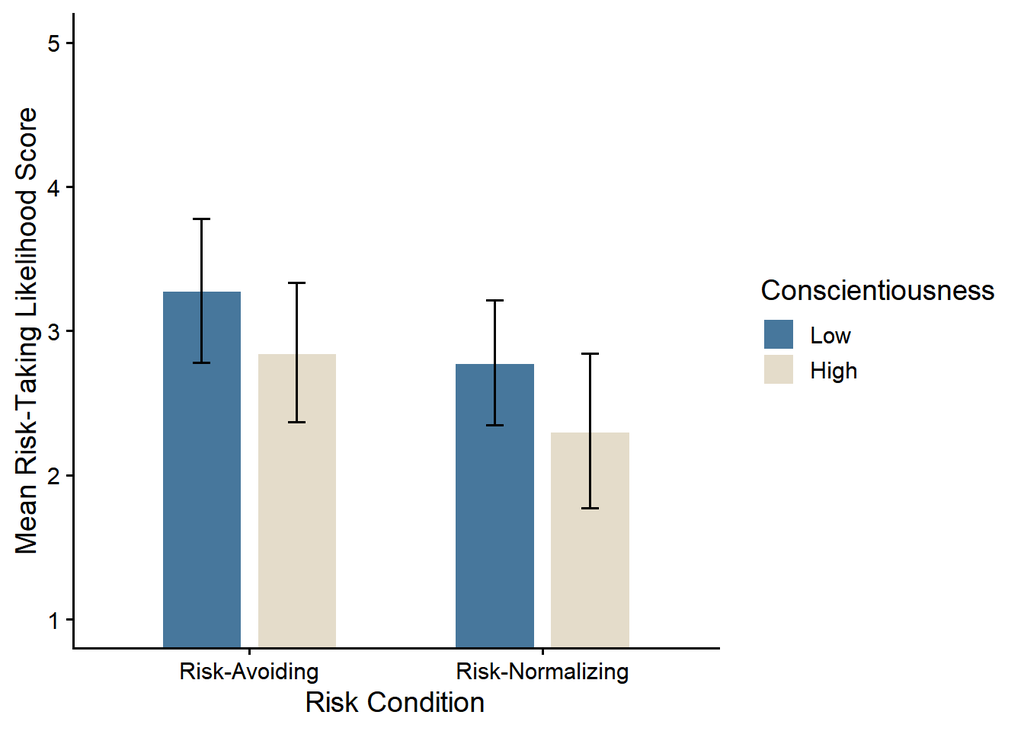

```r
risk_cell_means <- as.data.frame(
  emmeans(a1_risk, ~ condition * conscientiousness_msplit)
)

p_risk_bar <- ggplot(
  risk_cell_means,
  aes(
    x = condition,
    y = emmean,
    fill = conscientiousness_msplit
  )
) +
  geom_col(
    position = position_dodge(width = 0.65),
    width = 0.55,
    color = "white"
  ) +
  geom_errorbar(
    aes(
      ymin = lower.CL,
      ymax = upper.CL
    ),
    position = position_dodge(width = 0.65),
    width = 0.12,
    linewidth = 0.7
  ) +
  labs(
    x = "Risk Condition",
    y = "Mean Risk-Taking Likelihood Score",
    fill = "Conscientiousness"
  ) +
  scale_fill_manual(
    values = c(
      "Low" = "#47779c",  # YOU CAN CHANGE THESE TWO HEX VALUES TO MATCH YOUR POSTER!
      "High" = "#e4dcca"  # YOU CAN CHANGE THESE TWO HEX VALUES TO MATCH YOUR POSTER!
    )
  ) +
  scale_y_continuous(breaks = 1:5) +
  coord_cartesian(ylim = c(1, 5)) +
  theme_classic(base_size = 14)

p_risk_bar
```

This code generates a graph to compare levels of Mean Risk-Taking Likelihood Score between risk conditions (Risk-Avoiding vs. Risk-Normalizing), and is color-coded to indicate the High and Low Conscientiousness groups.

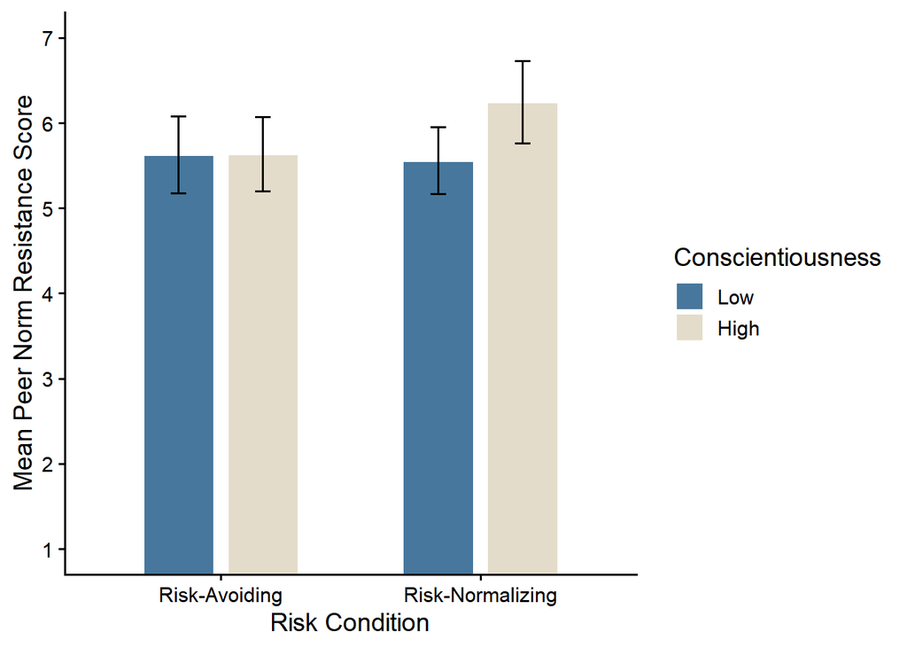

```r
peer_cell_means <- as.data.frame(
  emmeans(a1_peer, ~ condition * conscientiousness_msplit)
)

p_peer_bar <- ggplot(
  peer_cell_means,
  aes(
    x = condition,
    y = emmean,
    fill = conscientiousness_msplit
  )
) +
  geom_col(
    position = position_dodge(width = 0.65),
    width = 0.55,
    color = "white"
  ) +
  geom_errorbar(
    aes(
      ymin = lower.CL,
      ymax = upper.CL
    ),
    position = position_dodge(width = 0.65),
    width = 0.12,
    linewidth = 0.7
  ) +
  labs(
    x = "Risk Condition",
    y = "Mean Peer Norm Resistance Score",
    fill = "Conscientiousness"
  ) +
  scale_fill_manual(
    values = c(
      "Low" = "#47779c",  # YOU CAN CHANGE THESE TWO HEX VALUES TO MATCH YOUR POSTER!
      "High" = "#e4dcca"  # YOU CAN CHANGE THESE TWO HEX VALUES TO MATCH YOUR POSTER!
    )
  ) +
  scale_y_continuous(breaks = 1:7) +
  coord_cartesian(ylim = c(1, 7)) +
  theme_classic(base_size = 14)

p_peer_bar
```

## Export Figures

```r
if (!dir.exists("figures")) {
  dir.create("figures")
}

ggsave(
  filename = "figures/risk_taking_interaction_plot.svg",
  plot = p_risk_bar,
  width = 7,
  height = 5
)

ggsave(
  filename = "figures/peer_norm_resistance_interaction_plot.svg",
  plot = p_peer_bar,
  width = 7,
  height = 5
)
```

This chunk of code saves the generated interaction plots as SVG files, and exports both the risk-taking and peer norm resistance plots with consistent dimenions, so that they are ready for use in reports or presentations.

## Results Summary

This study aimed to explore how Perceived Peer Norms and Conscientiousness might influence levels of Risky Decision-Making in UC Santa Barbara undergraduate students. Despite our initial hypotheses’ predictions that Risk-Normalizing peer norms might correlate with higher levels of Risky Decision-Making, the opposite was actually true: Risk-Avoiding peer norms actually correlated with higher levels of Risky Decision-Making. There were no statistically significant effects found for Conscientiousness (individually), the interaction between Conscientiousness and Perceived Peer Norms conditions, or any of the effects (individual or interacting) on Peer Norm Resistance. Future research could benefit from employing measures with improved validity (i.e., more realistic examples of peer influence), or testing other personality traits.